# Extra details for the workshop

Matteo Fasiolo

August 20 2019

Things that might not have been explained, but you might find in some of the exercises:

- 1. the use of `offset()` in model formulas
- 2. how to extract smooth effects using `sm` and add layers to plots in `mgcViz`
- 3. how to use the `select = TRUE` argument in `gam` to do variable selection
- 4. the use of the `id` argument as in `s(x, id = 1) + s(x, id = 2)`
- 5. plotting differences between smooth effects using `plotDiff` in `mgcViz`
- 6. plotting multiple slices of multi-dimensional smooth effects using `plotSlice` in `mgcViz`

Here we provide very basic explanations for each.

### 1) Use of `offset()`

Suppose we want to model fish egg counts $y$ as a function of spatial location and of other factors `x` (as in one of the exercises). If we use a Poisson model with log-link then our model for the expected number of eggs is:
$$\log{\mathbb{E}(y|{\bf x})} = f_1({\bf x}) + \cdots + f_m({\bf x}),$$
or equivalently
$$\mathbb{E}(y|{\bf x}) = \exp \{f_1({\bf x}) + \cdots + f_m({\bf x}) \}.$$
Suppose that the $i$-th egg count $y_i$ has been obtained using a fishing net of $m_i$ square meters. Then $\mathbb{E}(y_i|x_i)$ should be directly proportional $m_i$. That is, we don’t want to estimate the effect of $m$ because it is clear that (everything else being equal) double $m$ will doubling the expected number of eggs we will catch. Hence we would like our model to be
$$\log{\mathbb{E}(y|{\bf x})} = \log(m) + f_1({\bf x}) + \cdots + f_m({\bf x}),$$
so that
$$\mathbb{E}(y|{\bf x}) = m\exp \{f_1({\bf x}) + \cdots + f_m({\bf x}) \}.$$
This can be achieved by adding an `offset` terms to the linear predictor:

```r
fit <- gam(eggs ~ offset(log.m) + s(x), family = poisson(link = "log"))
```

where `log.m` is $\log(m)$.

### 2) Extracting smooth effects using `sm()` and adding layers to plots

Suppose we are fitting this model

```r
library(mgcViz)
dat <- gamSim(1,n=1000,dist="normal",scale=2)
```

```
## Gu & Wahba 4 term additive model
```

```r
b <- gamV(y ~ x0+s(x1, x2)+s(x3), data=dat)
```

We could plot the estimated effects as usual using `plot(fit)` but, alternatively, we can extract individual smooth effects using `sm` and then plot them:

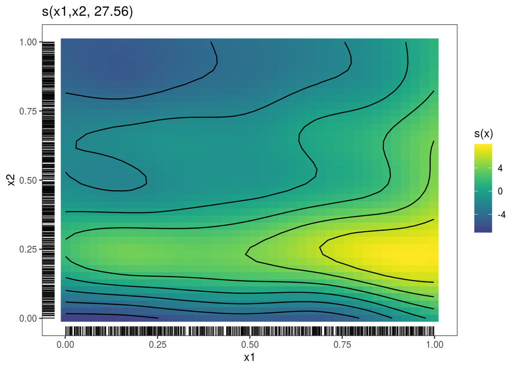

```r
s1 <- sm(b, 1)
plot(s1) + l_rug() + l_fitRaster() + l_fitContour()
```

The functions starting with `l_` are graphical layers, similar to `ggplot` layers. To see which layes are available for a particular effect we can do:

```r
listLayers( plot(s1) )
```

```
## [1] "l_den"        "l_fitContour" "l_fitRaster"  "l_points"
## [5] "l_pvContour"  "l_pvRaster"   "l_rug"
```

which prints out a list of available layers. We can do the same for parametric effects, using the `pterm` function:

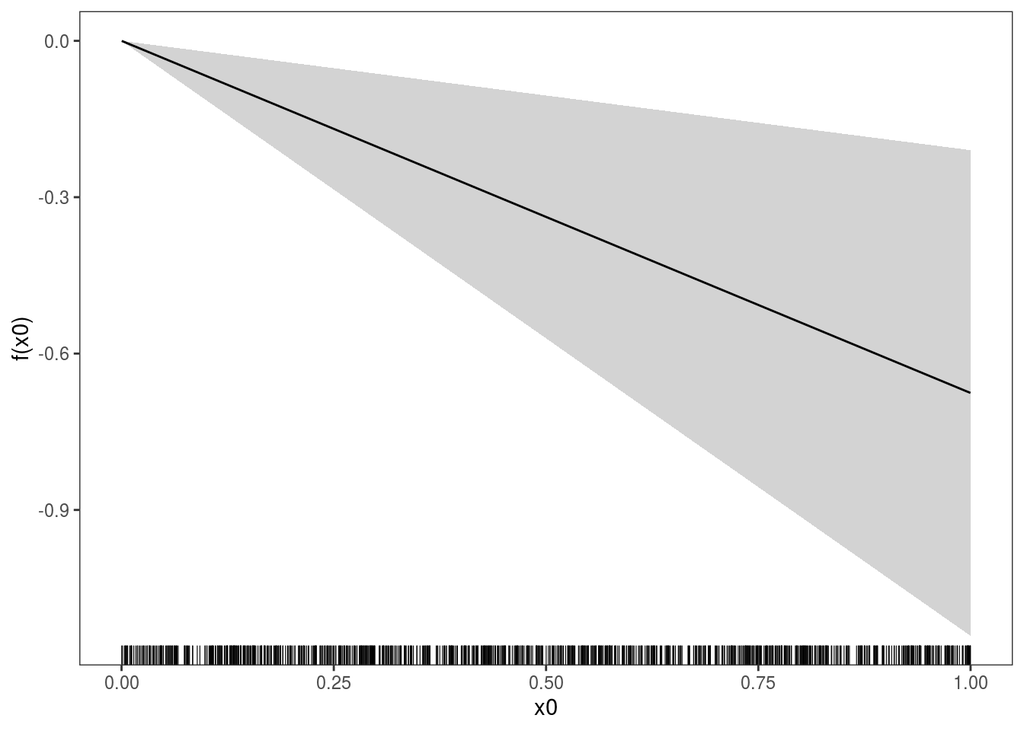

```r
p1 <- pterm(b, 1)
plot(p1) + l_rug() + l_ciPoly() + l_fitLine()
```

### 3) Using `select = TRUE` in `gam` to do variable selection

We simulate data from the model
$$y = x^2 + e, \;\;\; e \sim N(0, \sigma^2),$$
by doing:

```r
set.seed(42424)
n <- 1000
x <- runif(n, -1, 1)
dat <- data.frame(y = x^2 + rnorm(n, 0, 1), x = x, z = runif(n, -1, 1))
```

Notice that I have added an extra variable `z` which has nothing to do with the distribution of `y`. Now I fit the model

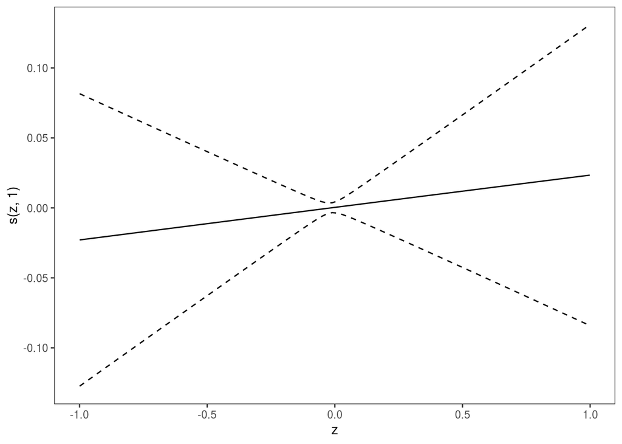

```r
fit <- gamV(y ~ s(x) + s(z), data = dat)
plot(fit, select = 2)
```

Notice that the estimated effect of `z`, while weak, is not zero. This is because the penalty used by `mgcv` penalises the curvature of `s(z)`, not its slope. To penalise also the slope of the effect `s(z)` we can use the `select` argument:

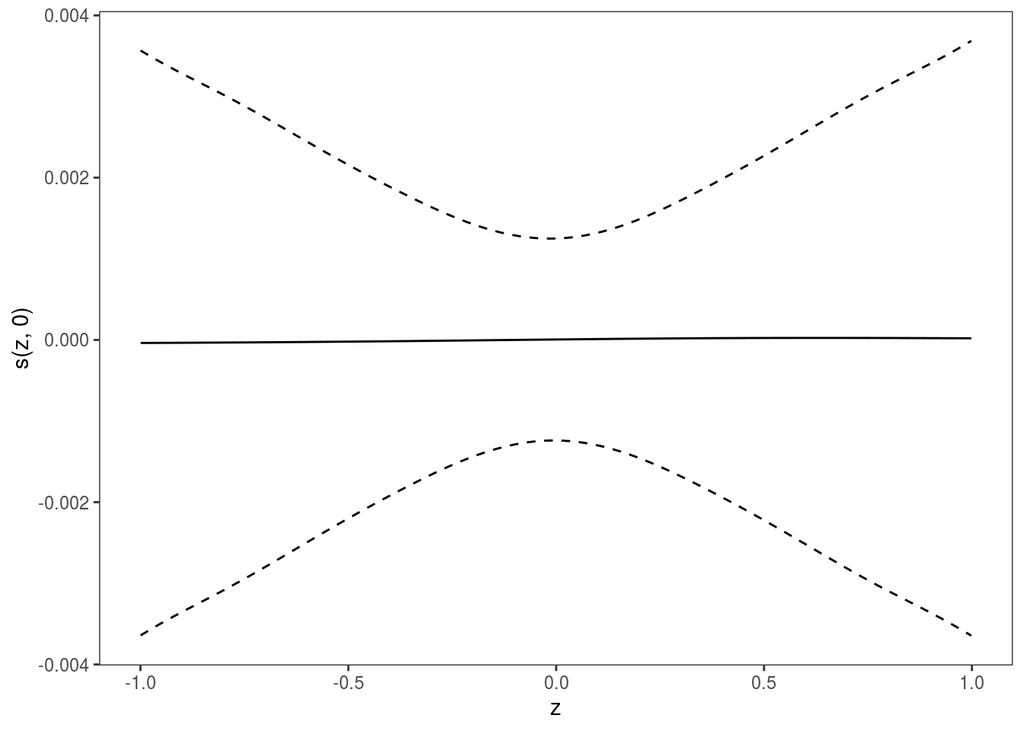

```r
fit <- gamV(y ~ s(x) + s(z), data = dat, aGam = list(select = TRUE))
print(plot(fit, select = 2), page = 1)
```

Now the whole effect, that is both its smooth and parametric part, has been effectively removed from the fit.

### 4) Using the `id` argument when creating smooth effects

Suppose we are fitting a model with two by-factor smooth:

```r
fit <- gamV(y ~ s(x1, by = Factor1) + s(z2, by = Factor2) + s(x3), ...)
```

By default the smoothing parameter of `s(x1)` will be different for each level of factor variable `Factor1`. Same for `s(x2)` and `Factor2`. We can make so that only one smoothing parameter will be used for each of the two by-factor effects by doing:

```r
fit <- gamV(y ~ s(x1, by = Factor1, id = 1) + s(z2, by = Factor2, id = 2) + s(x3), ...)
```

This model has 3 smoothing parameters, so all the smooths along `x1` have the same smootness penalty. Same for `x2`. If we do:

```r
fit <- gamV(y ~ s(x1, by = Factor1, id = 1) + s(z2, by = Factor2, id = 1) + s(x3), ...)
```

Then we are using only 2 smoothing parameters, and all the smooths along `x1` and `x2` have the same penalty (which is typically undesirable). See `?s` for more details.

### 5) Differences-between-smooths plots

Plotting the difference between two smooth effects can be useful when working with by-factor smooths. For example, here we are fitting a model containing a smooth along `x2` for each value of the `fac` factor variable:

```r
set.seed(6898)
dat <- gamSim(1,n=500,dist="normal",scale=20)
dat$fac <- as.factor( sample(c("A1", "A2", "A3"), nrow(dat), replace = TRUE) )
bs <- "cr"; k <- 12
b <- gam(y ~ s(x2,bs=bs,by = fac), data=dat)
b <- getViz(b)
```

We can plot the difference between the smooths corresponding to levels `"A1"` and `"A2"`, by extracting the two smooths and then feeding them to the `plotDiff` generic:

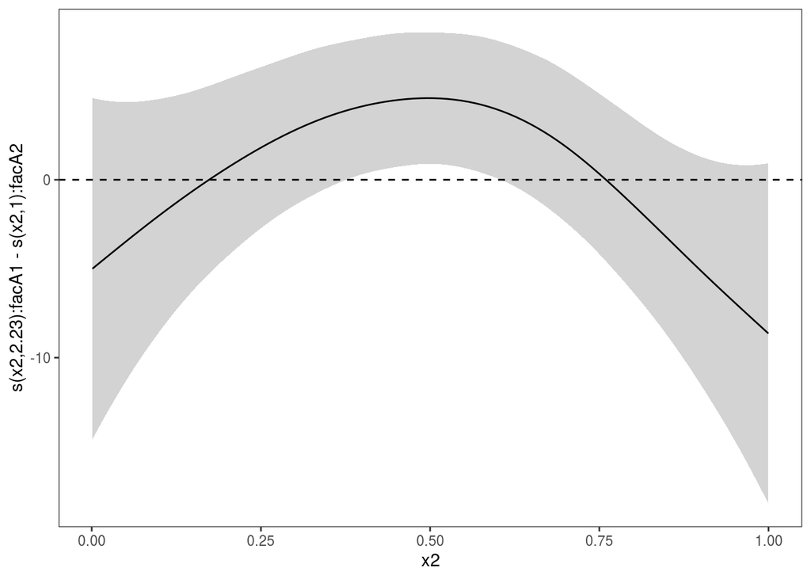

```r
plotDiff(s1 = sm(b, 1), s2 = sm(b, 2)) + l_ciPoly() +
         l_fitLine() + geom_hline(yintercept = 0, linetype = 2)
```

Notice that the credible intervals for the difference smooth produced by `plotDiff` take into account the cross-covariance between the two smooths.

### 6) Plotting multiple slices of multi-dimensional smooth effects

When dealing with smooth effects defined on more than two dimensions, it is often useful to visualize them as a sequence of 2D slices. The `plotSlice` function provides such functionality, by exploiting the faceting tools offerered by `ggplot2`. For instance, here we are slicing a 4D smooth effect along two variables:

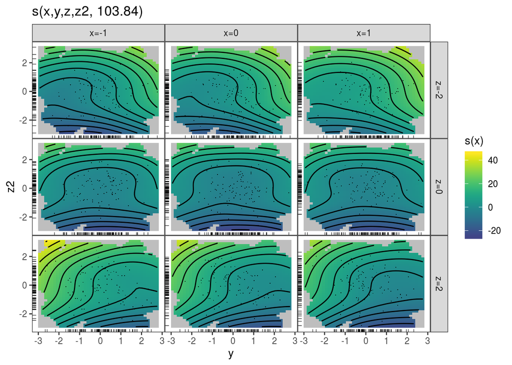

```r
n <- 1e3
x <- rnorm(n); y <- rnorm(n); z <- rnorm(n); z2 <- rnorm(n)
ob <- (x-z)^2 + (y-z)^2 + z2^3 + rnorm(n)
b <- gam(ob ~ s(x, y, z, z2))
v <- getViz(b)

# Plot slices across "z" and "x"
pl <- plotSlice(x = sm(v, 1),
                fix = list("z" = seq(-2, 2, length.out = 3), "x" = c(-1, 0, 1)))
pl + l_fitRaster() + l_fitContour() + l_points() + l_rug()
```